# Identify recurrent cluster features

Crystal Shan

2026-11-12

This analysis is to identify recurrent clusters from individual examples, I previously did clustering on housekeeping, cell type specific and not expressed genes in `/project/spott/cshan/fiber-seq/code/pausing/PolII` using example genes in `/project/spott/cshan/fiber-seq/code/pausing/PolII/example_gene_list.tsv`

I want to know if there is

1. features representative for each gene groups?
2. features shared across different gene groups?

```r
show_pdf_pages <- function(pdf, dpi = 100) {
  out <- tempfile()
  status <- system2("/project/spott/cshan/envs/poppler/bin/pdftoppm",
                    c("-png", "-r", dpi, shQuote(pdf), shQuote(out)))
  pngs <- sort(Sys.glob(paste0(out, "-*.png")))
  if (status != 0 || !length(pngs)) stop("pdftoppm failed on ", pdf)
  pngs
}
```

# Gene and read level accessibility and nucleosome occupancy features

From each gene, I extracted the read features:

I classified each read into 4 broad categories: 1) **A1 open / +1-depleted** - TSS base is nucleosome-free and no nucleosome begins in the first 300 bp downstream, so the fiber is open with no positioned +1 (26,801 reads) 2) **A2 open / +1-enriched** - TSS base is nucleosome-free but a nucleosome begins within +0..+299, the canonical open promoter with a positioned +1 (35,939 reads) 3) **A3 occluded / +1-depleted** - A nucleosome covers the TSS base and no further nucleosome begins within +0..+299, so the fiber is closed at the start site with the downstream region unoccupied (5,408 reads) 4) **A4 occluded / +1-enriched** - A nucleosome covers the TSS base and a separate nucleosome begins within +0..+299, so the fiber is closed with an additional positioned downstream nucleosome (7,128 reads)

1. `LCL_project/pausing/PolII/read_features/tables/read_features.tsv.gz`

| Column | Meaning |
| --- | --- |
| `gene` | Gene symbol the window belongs to. |
| `group` | Curated class: `housekeeping`, `cell_type_specific` or `not_expressed`. |
| `chrom` | Chromosome of the TSS. |
| `tss` | TSS position, 1-based. FANTOM5 LCL dominant TSS, or GENCODE v46 canonical as fallback. |
| `strand` | Gene strand. All offsets below are oriented by transcription, so offset 0 is the TSS base and positive is downstream. |
| `RID` | Read identifier, namespaced as `<sample>::<read name>`. |
| `sample_name` | LCL sample the read came from (31 merged samples). |
| `start` | Read alignment start, 1-based inclusive. |
| `end` | Read alignment end, 1-based inclusive. |
| `m6a_total` | m6A fraction over the whole window (offsets −1000..1000), averaged over observed sites only. |
| `m6a_core` | m6A fraction over the core promoter, offsets −200..200. |
| `m6a_upstream` | m6A fraction over offsets −500..−201. |
| `m6a_downstream` | m6A fraction over offsets 201..500. |
| `m6a_far_up` | m6A fraction over offsets −1000..−501. |
| `m6a_far_down` | m6A fraction over offsets 501..1000. |
| `nuc_total` | Fraction of the 2,001 window bases covered by a 130–160 bp fibertools nucleosome call. |
| `nuc_core` | Same, restricted to offsets −200..200. |
| `tf_10_30_total` | Fraction of window bases covered by a FiberHMM 10–30 bp footprint. |
| `tf_10_30_core` | Same, restricted to offsets −200..200. |
| `tf_30_60_total` | Fraction of window bases covered by a FiberHMM 30–60 bp footprint. |
| `tf_30_60_core` | Same, restricted to offsets −200..200. |
| `tf_60_80_total` | Fraction of window bases covered by a FiberHMM 60–80 bp footprint. |
| `tf_60_80_core` | Same, restricted to offsets −200..200. |
| `nuc_at_tss` | `TRUE` when a nucleosome call covers offset 0 |
| `plus1` | First offset in 0..299 *covered* by a nucleosome; `NA` if none. Original `plus1_offset()` definition, used for read ordering in the figures. |
| `plus1_start` | First offset in 0..299 at which a nucleosome *starts*, excluding any nucleosome that covers the TSS; `NA` if none. Independent of `nuc_at_tss`. |
| `archetype` | `A1 open / +1-depleted`, `A2 open / +1-enriched`, `A3 occluded / +1-depleted` or `A4 occluded / +1-enriched` |

```r
read_feature_table <- read.delim("/project/spott/cshan/fiber-seq/LCL_project/pausing/PolII/read_features/tables/read_features.tsv.gz")
print(head(read_feature_table))
```

```
##   gene              group chrom       tss strand
## 1 CD74 cell_type_specific  chr5 150412751      -
## 2 CD74 cell_type_specific  chr5 150412751      -
## 3 CD74 cell_type_specific  chr5 150412751      -
## 4 CD74 cell_type_specific  chr5 150412751      -
## 5 CD74 cell_type_specific  chr5 150412751      -
## 6 CD74 cell_type_specific  chr5 150412751      -
##                                                       RID      sample_name
## 1 AL6_bc2162_19093::m84241_241120_172940_s3/152703583/ccs AL6_bc2162_19093
## 2 AL6_bc2162_19093::m84241_241120_172940_s3/176423596/ccs AL6_bc2162_19093
## 3 AL6_bc2162_19093::m84241_250514_222554_s2/119477393/ccs AL6_bc2162_19093
## 4 AL8_bc2170_19151::m84241_241120_172940_s3/160695644/ccs AL8_bc2170_19151
## 5  AL8_bc2170_19151::m84241_241120_172940_s3/99682577/ccs AL8_bc2170_19151
## 6 AL8_bc2170_19151::m84241_250325_230544_s1/110625035/ccs AL8_bc2170_19151
##       start       end m6a_total  m6a_core m6a_upstream m6a_downstream
```

[output cut: 27 more lines]

bar plot showing the archetype for different gene groups

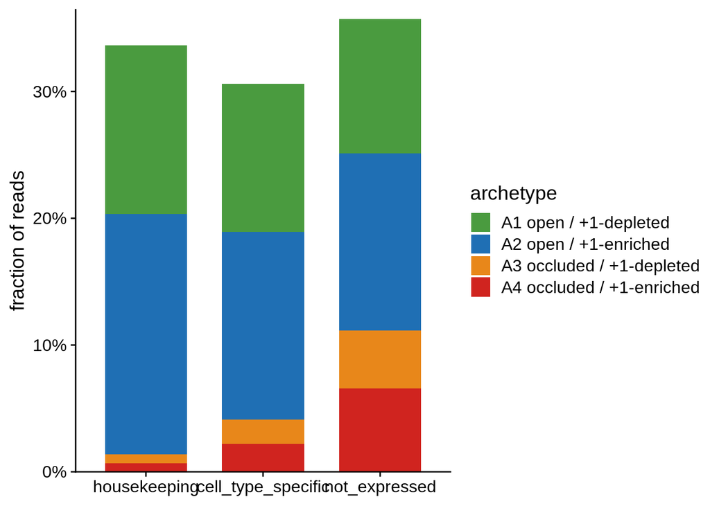

```r
GROUP_LEVELS <- c("housekeeping", "cell_type_specific", "not_expressed")
ARCHETYPE_COLORS <- c("A1 open / +1-depleted"     = "#4a9b3f",
                      "A2 open / +1-enriched"     = "#1f6fb4",
                      "A3 occluded / +1-depleted" = "#e8871a",
                      "A4 occluded / +1-enriched" = "#d0241f")


subset_gene_archetype <- read_feature_table %>%
  select(group, archetype) %>%
  count(group, archetype, name = "n_reads") %>%
  mutate(fraction = n_reads / sum(n_reads)) %>%
  ungroup() %>%
  mutate (
    group = factor(group, levels = GROUP_LEVELS),
    archetype = factor(archetype, levels = names(ARCHETYPE_COLORS))
  )

ggplot(subset_gene_archetype, aes(x = group, y = fraction, fill = archetype)) +
  geom_col(width = 0.7) +
  scale_fill_manual(values = ARCHETYPE_COLORS) +
  scale_y_continuous(labels = scales::percent, expand = expansion(mult = c(0, 0.02))) +
  labs(x = NULL, y = "fraction of reads", fill = "archetype") +
  theme_cowplot()
```

2. `bins/<gene>.tsv.gz` - gene level features per 10 bp bins, one row per read x 10 bp bins

| Column | Meaning |
| --- | --- |
| `gene` | Gene symbol. |
| `RID` | Read identifier, joins to `read_features.tsv.gz` on `gene` + `RID` |
| `bin` | Bin index 0–199 across the TSS ±1 kb window, oriented by transcription |
| `position` | Bin centre in bp from the TSS: −995, −985, … , 995 |
| `m6a_sites` | Observed m6A sites in this bin. A per-gene constant, repeated on every read’s row |
| `bin_bases` | Genomic bases in this bin: 10 for bins 0–198, 11 for bin 199, which absorbs offset +1000 |
| `m6a_calls` | m6A calls on this read within this bin |
| `nuc_bases` | Bases of this bin covered on this read by a 130–160 bp nucleosome call |
| `tf_10_30_bases` | Bases covered on this read by a FiberHMM 10–30 bp footprint |
| `tf_30_60_bases` | Bases covered on this read by a FiberHMM 30–60 bp footprint |
| `tf_60_80_bases` | Bases covered on this read by a FiberHMM 60–80 bp footprint |

```r
# take SCYGR1 gene as an example
example_binned_table <- read.delim("/project/spott/cshan/fiber-seq/LCL_project/pausing/PolII/read_features/bins/SCYGR1.tsv.gz")
print(head(example_binned_table))
```

```
##     gene                                                     RID bin position
## 1 SCYGR1 AL6_bc2162_19093::m84241_241120_172940_s3/219875480/ccs   0     -995
## 2 SCYGR1  AL6_bc2162_19093::m84241_241120_172940_s3/47320621/ccs   0     -995
## 3 SCYGR1 AL6_bc2162_19093::m84241_250514_222554_s2/103812522/ccs   0     -995
## 4 SCYGR1 AL6_bc2162_19093::m84241_250514_222554_s2/118624744/ccs   0     -995
## 5 SCYGR1 AL6_bc2162_19093::m84241_250514_222554_s2/266015498/ccs   0     -995
## 6 SCYGR1  AL6_bc2162_19093::m84241_250514_222554_s2/92279805/ccs   0     -995
##   m6a_sites bin_bases m6a_calls nuc_bases tf_10_30_bases tf_30_60_bases
## 1         4        10         0         0              0              0
## 2         4        10         0         0              0              0
## 3         4        10         0        10              0              0
## 4         4        10         0         0              0              0
## 5         4        10         0        10              0              0
## 6         4        10         0         0              0              0
##   tf_60_80_bases
## 1              0
## 2              0
## 3              0
## 4              0
## 5              0
## 6              0
```

3. `tables/gene_features.tsv` - one row per gene

| Column | Meaning |
| --- | --- |
| `group` | Curated class of the gene. |
| `gene_name` | Gene symbol. |
| `gene_id` | Ensembl gene ID. |
| `chrom` | Chromosome. |
| `tpm_rep1` | GM12878 TPM, ENCODE ENCSR820PHH replicate 1. |
| `tpm_rep2` | GM12878 TPM, replicate 2. |
| `tpm_mean` | Mean of the two replicate TPMs. |
| `status` | `complete`, or `error` when the gene could not be extracted. |
| `error` | Error message for failed genes, empty otherwise. |
| `tss` | Resolved TSS, 1-based. `NA` if the gene failed. |
| `strand` | Gene strand. |
| `tss_source` | `FANTOM5 dominant TSS` or `GENCODE v46 canonical TSS`. |
| `n_reads` | Full-span reads in the window. |
| `n_samples` | Distinct LCL samples contributing reads. |
| `occluded_fraction` | Fraction of reads whose TSS base is covered by a nucleosome. |
| `plus1_fraction` | Fraction of reads with a `plus1_start`, i.e. a +1 nucleosome that does not cover the TSS. |
| `m6a_total` | Mean of the reads’ `m6a_total`. |
| `m6a_core` | Mean of the reads’ `m6a_core`. |
| `m6a_upstream` | Mean of the reads’ `m6a_upstream`. |
| `m6a_downstream` | Mean of the reads’ `m6a_downstream`. |
| `m6a_far_up` | Mean of the reads’ `m6a_far_up`. |
| `m6a_far_down` | Mean of the reads’ `m6a_far_down`. |
| `nuc_total` | Mean of the reads’ `nuc_total`. |
| `nuc_core` | Mean of the reads’ `nuc_core`. |
| `tf_10_30_total` | Mean of the reads’ `tf_10_30_total`. |
| `tf_10_30_core` | Mean of the reads’ `tf_10_30_core`. |
| `tf_30_60_total` | Mean of the reads’ `tf_30_60_total`. |
| `tf_30_60_core` | Mean of the reads’ `tf_30_60_core`. |
| `tf_60_80_total` | Mean of the reads’ `tf_60_80_total`. |
| `tf_60_80_core` | Mean of the reads’ `tf_60_80_core`. |
| `nuc_at_tss` | Mean of the reads’ `nuc_at_tss`. Numerically identical to `occluded_fraction`. |
| `plus1` | Mean `plus1` offset over reads that have one, `NA` values dropped. |
| `plus1_start` | Mean `plus1_start` offset over reads that have one, `NA` values dropped. |
| `fraction_A1` | Fraction of reads in archetype A1, open / +1-depleted. |
| `fraction_A2` | Fraction of reads in archetype A2, open / +1-enriched. |
| `fraction_A3` | Fraction of reads in archetype A3, occluded / +1-depleted. |
| `fraction_A4` | Fraction of reads in archetype A4, occluded / +1-enriched. |

```r
gene_feature_table <- read.delim("/project/spott/cshan/fiber-seq/LCL_project/pausing/PolII/read_features/tables/gene_features.tsv")
print(head(gene_feature_table))
```

```
##                group gene_name         gene_id chrom tpm_rep1 tpm_rep2 tpm_mean
## 1 cell_type_specific      CD74 ENSG00000019582  chr5  1938.33  1884.27 1911.300
## 2 cell_type_specific   HLA-DRA ENSG00000204287  chr6   794.98   800.06  797.520
## 3 cell_type_specific  HLA-DRB1 ENSG00000196126  chr6   279.92   288.96  284.440
## 4 cell_type_specific  HLA-DQA1 ENSG00000196735  chr6   258.94   267.59  263.265
## 5 cell_type_specific      IRF4 ENSG00000137265  chr6   192.80   187.46  190.130
## 6 cell_type_specific  HLA-DPB1 ENSG00000223865  chr6   187.31   182.61  184.960
##     status error       tss strand           tss_source n_reads n_samples
## 1 complete       150412751      - FANTOM5 dominant TSS     453        31
## 2 complete        32439887      + FANTOM5 dominant TSS     101        18
## 3 complete        32589805      - FANTOM5 dominant TSS     134        14
## 4 complete        32637406      + FANTOM5 dominant TSS     205        23
## 5 complete          391752      + FANTOM5 dominant TSS     537        31
## 6 complete        33075990      + FANTOM5 dominant TSS      61        25
##   occluded_fraction plus1_fraction m6a_total  m6a_core m6a_upstream
```

[output cut: 34 more lines]

# examples genes clustered individually

```r
EXAMPLE_VIEWS <- c("unclustered/%s_unclustered_m6a", "unclustered/%s_unclustered_footprints",
                   "clustered/%s_clustered_m6a", "clustered/%s_clustered_footprints",
                   "read_level_plots/%s_read_level")

show_example_genes <- function(genes, group, dpi = 100) {
  pngs <- unlist(lapply(genes, function(sym) {
    a <- fread(file.path(OUT_DIR, "recurrent_patterns/tables", group, paste0(sym, "_read_clusters.tsv")))
    message(sym, ": ", nrow(a), " reads, ", uniqueN(a$cluster), " clusters")
    pdfs <- file.path(OUT_DIR, "plots/example_reads", group, sym, paste0(sprintf(EXAMPLE_VIEWS, sym), ".pdf"))
    stopifnot(file.exists(pdfs))
    vapply(pdfs, function(pdf) {
      out <- tempfile()
      status <- system2("/project/spott/cshan/envs/poppler/bin/pdftoppm",
                        c("-png", "-singlefile", "-r", dpi, shQuote(pdf), shQuote(out)))
      if (status != 0 || !file.exists(paste0(out, ".png"))) stop("pdftoppm failed on ", pdf)
      paste0(out, ".png")
    }, character(1))
  }))
  knitr::include_graphics(pngs)
}
```

## 1. housekeeping genes: B2M, ENO1

```r
show_example_genes(c("B2M", "ENO1"), "housekeeping")
```

```
## B2M: 377 reads, 5 clusters
```

```
## ENO1: 460 reads, 5 clusters
```

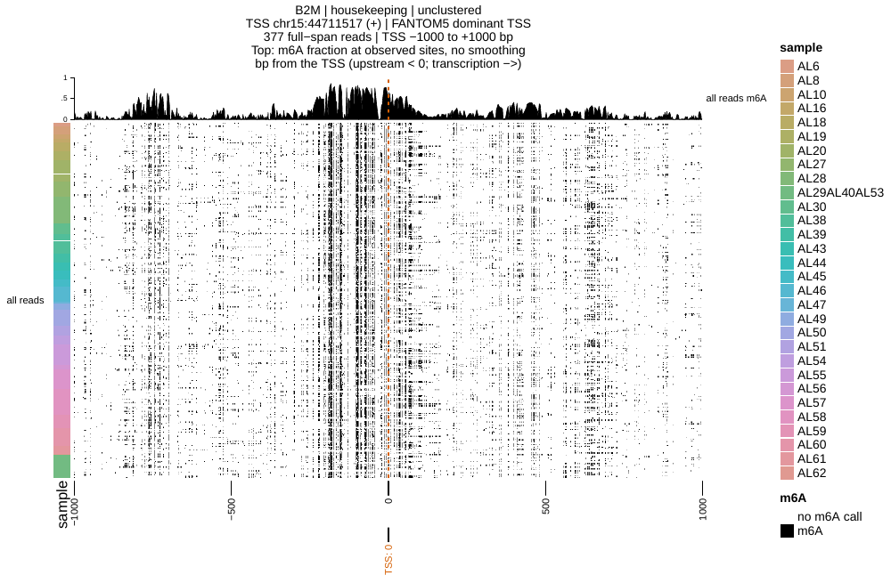

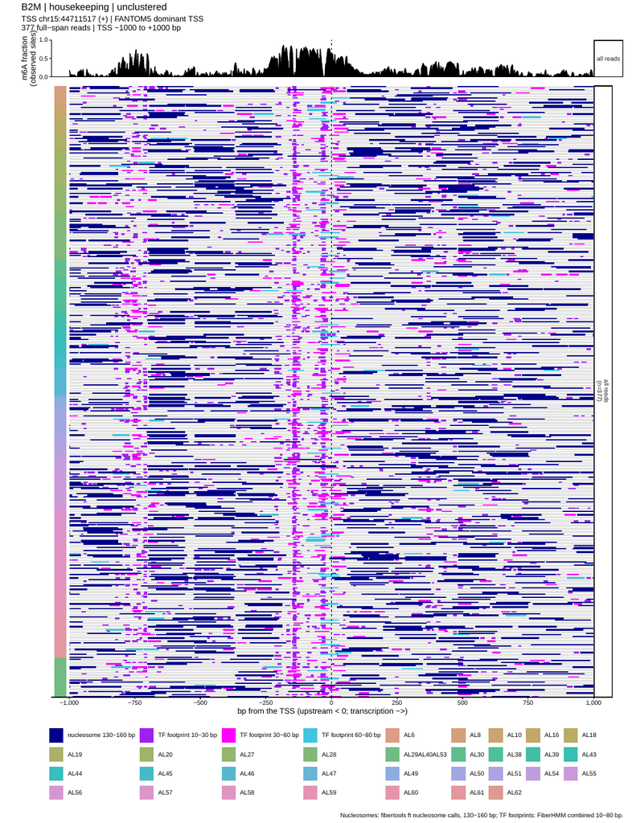

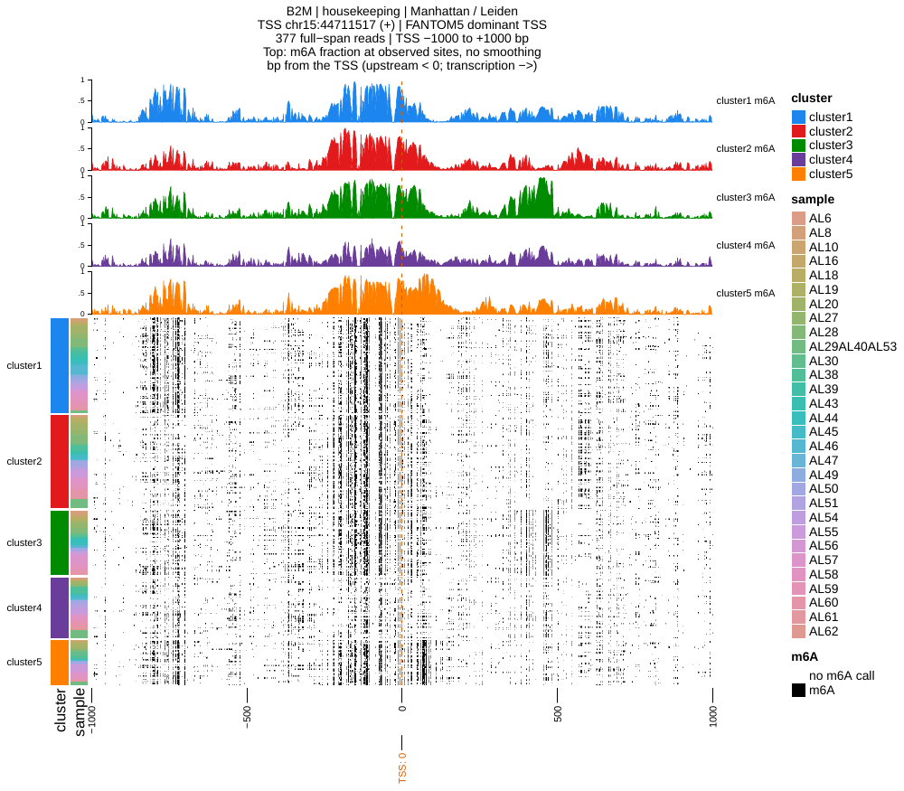

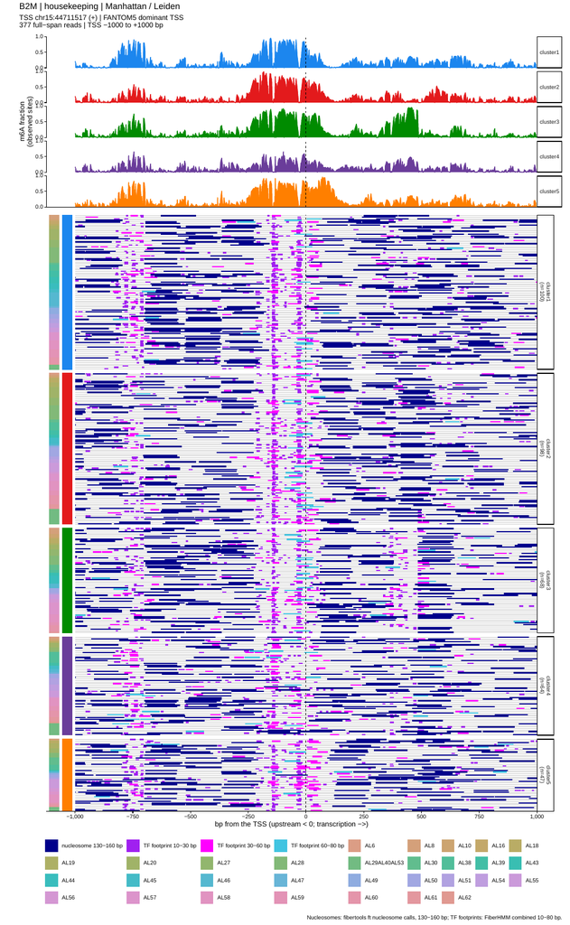

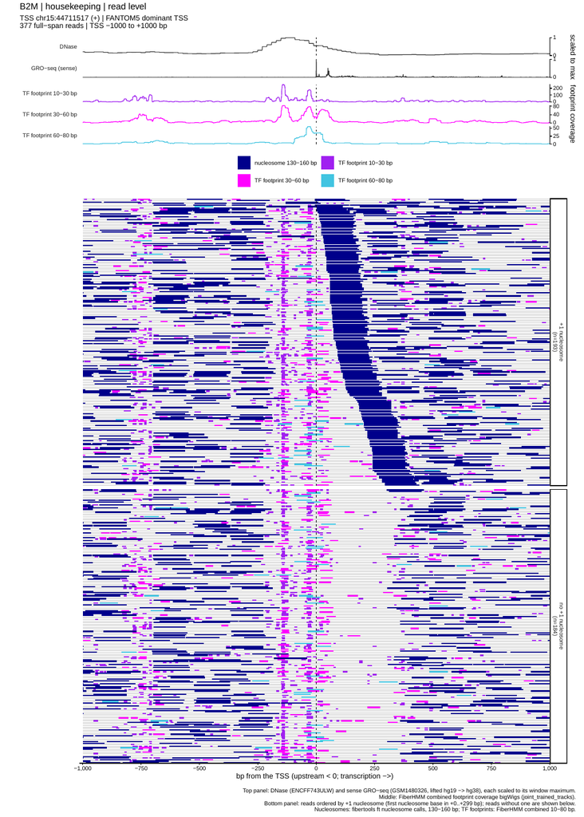

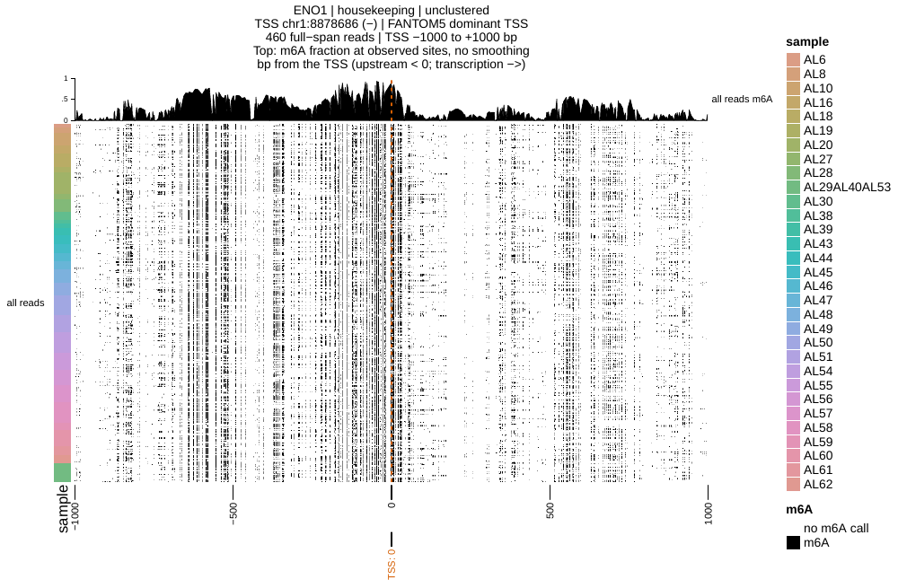

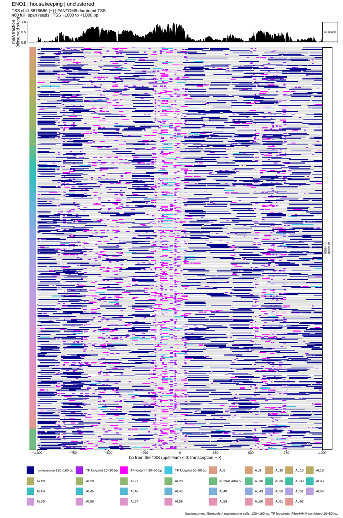

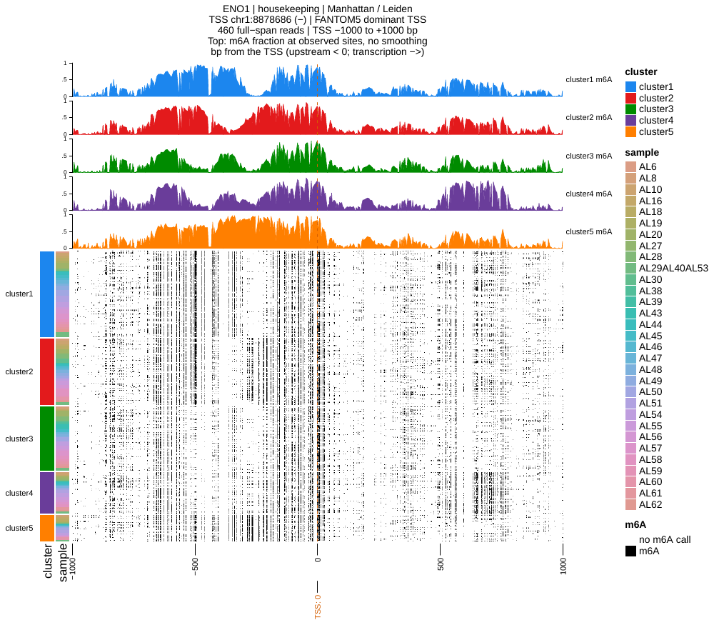

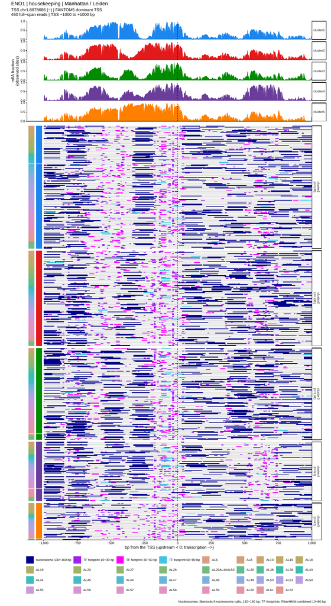

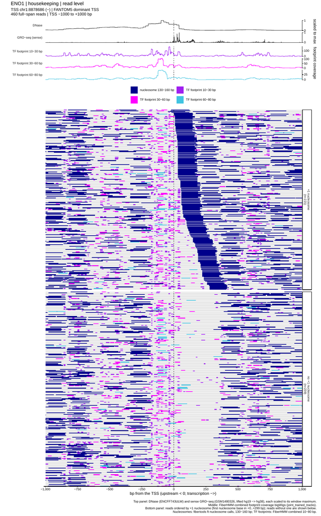

## 2. cell type specifc genes: NFKB2, BATF

```r
show_example_genes(c("NFKB2", "BATF"), "cell_type_specific")
```

```
## NFKB2: 358 reads, 7 clusters
```

```
## BATF: 576 reads, 6 clusters
```

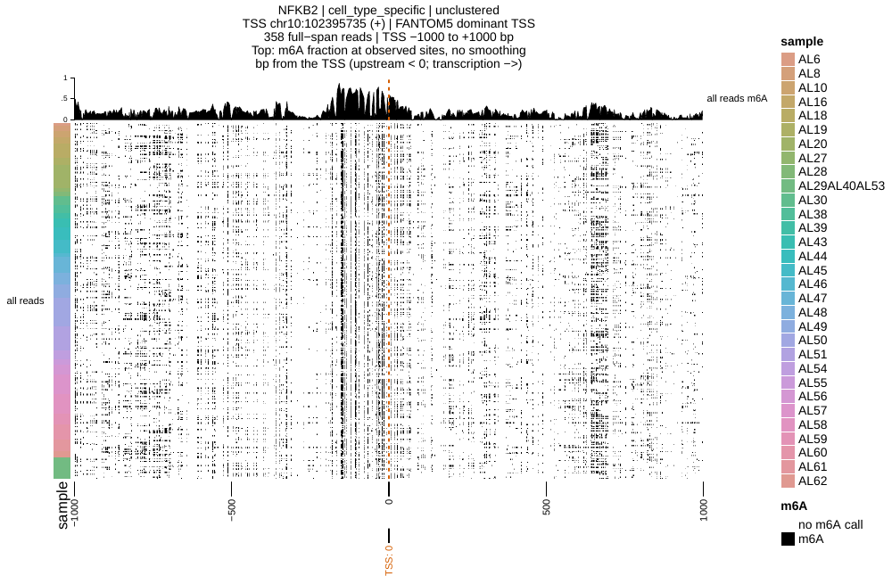

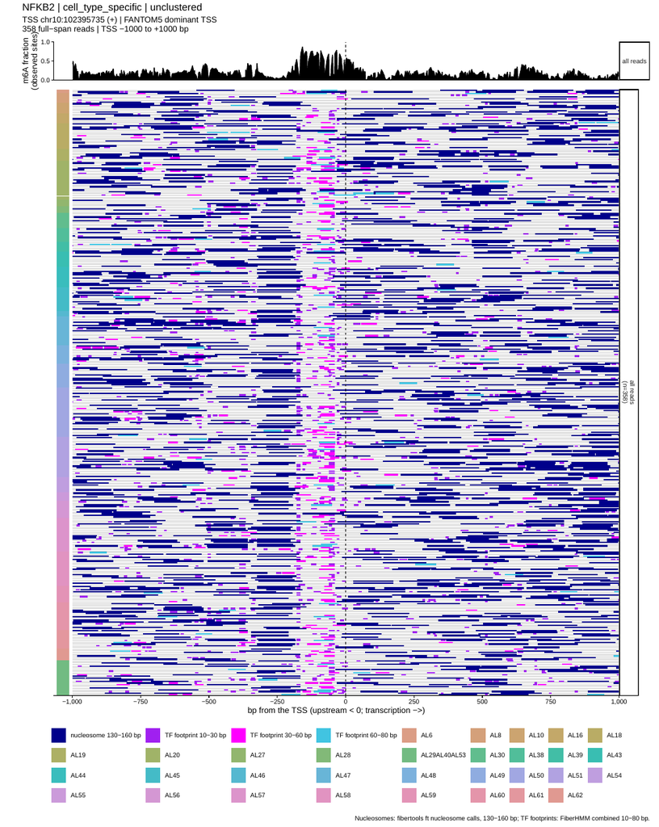

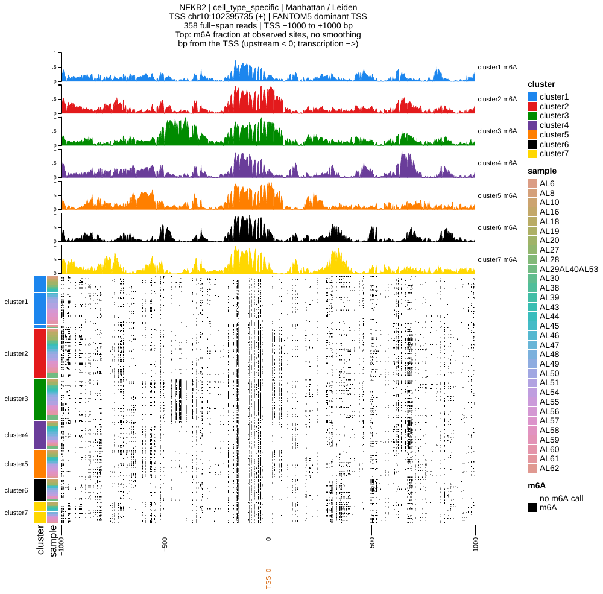

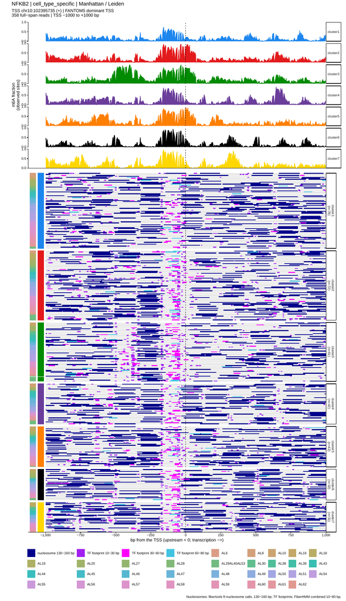

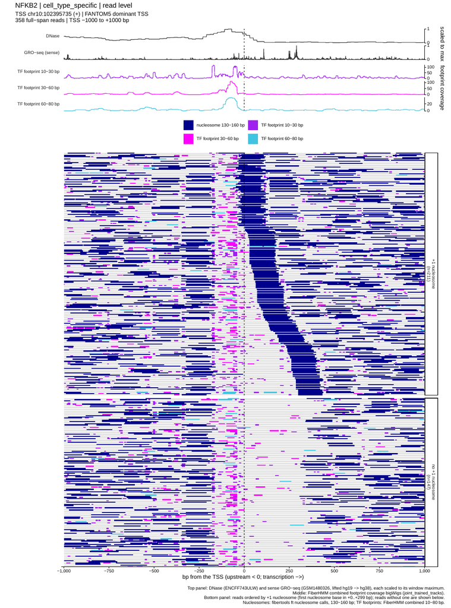

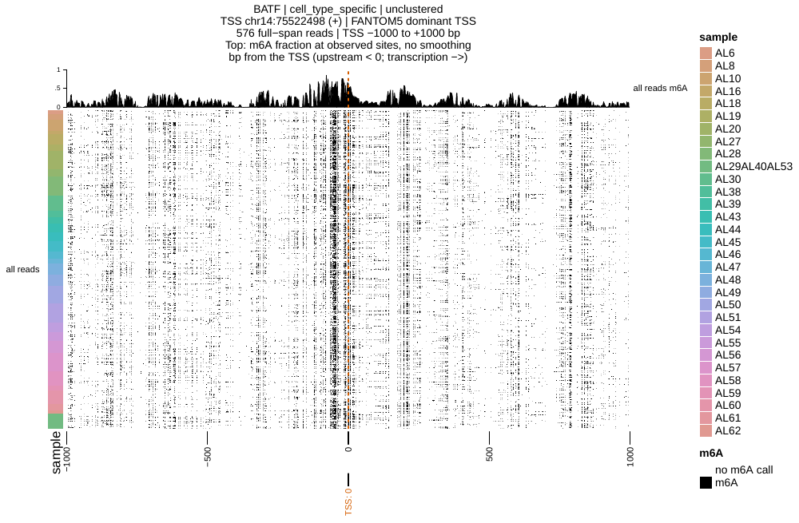

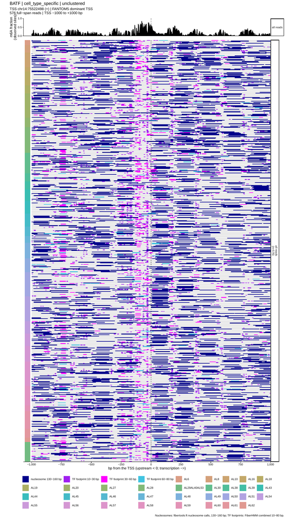

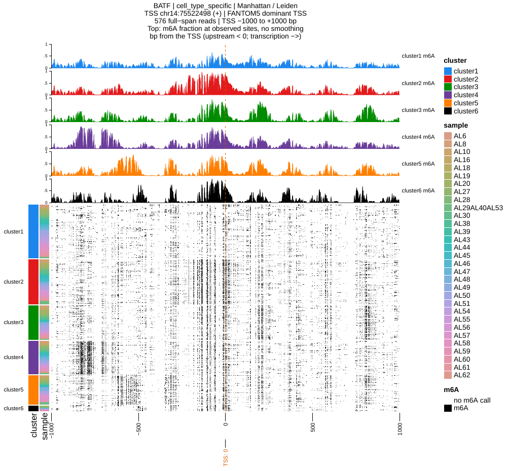

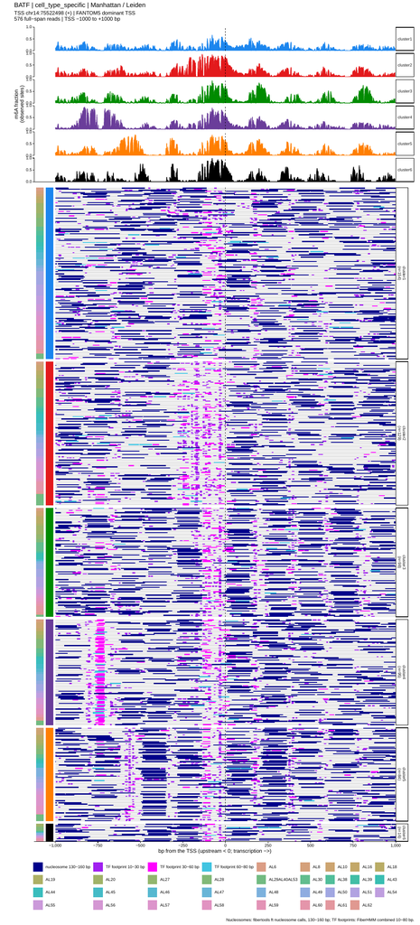

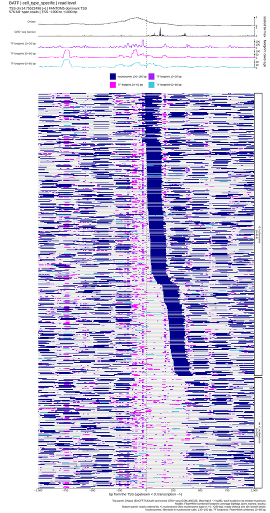

## 3. not expressed genes: APOBEC1, SUSD5

```r
show_example_genes(c("APOBEC1", "SUSD5"), "not_expressed")
```

```
## APOBEC1: 462 reads, 4 clusters
```

```
## SUSD5: 645 reads, 4 clusters
```

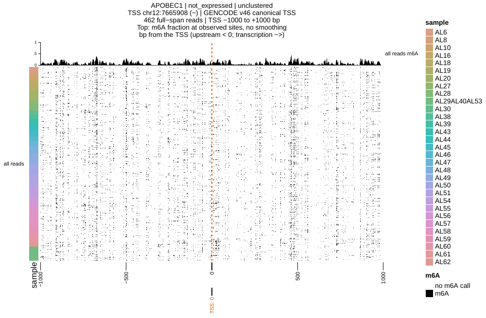

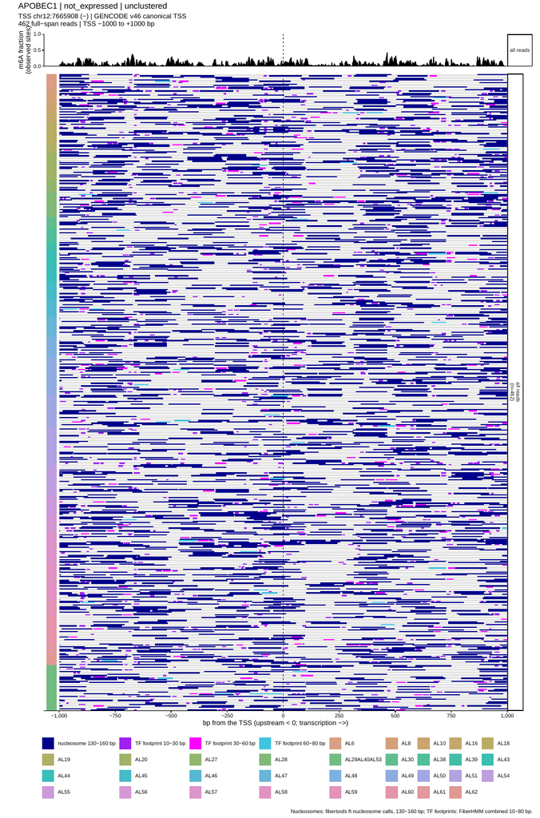

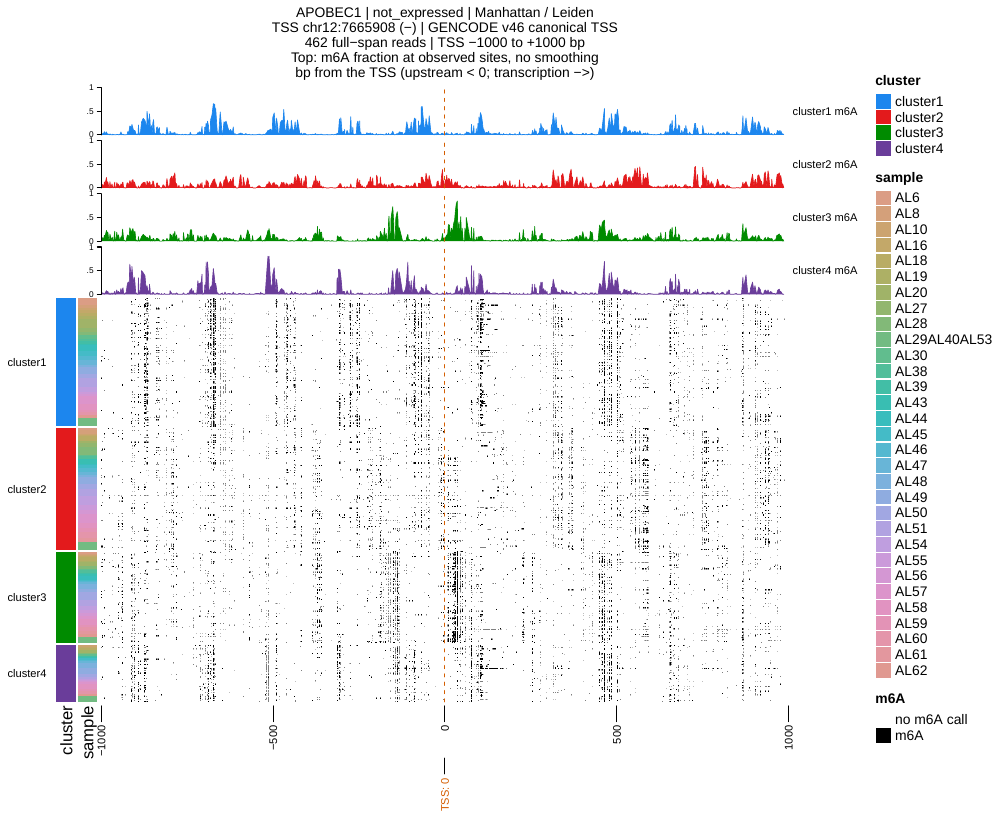

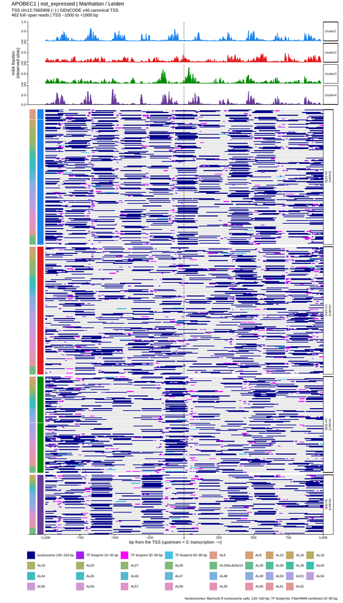

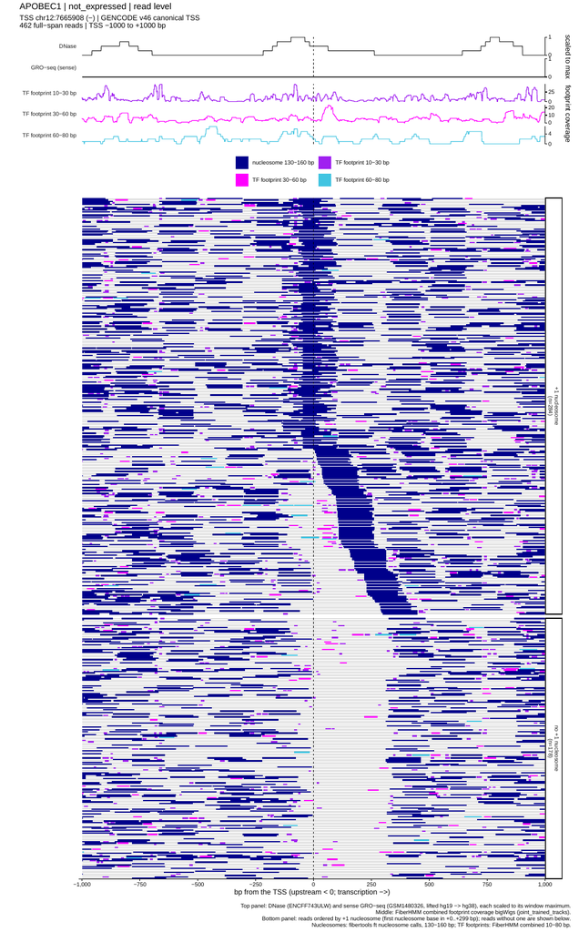

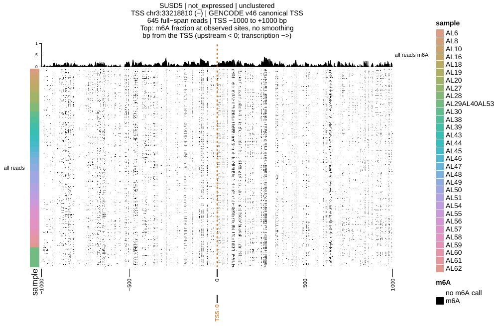

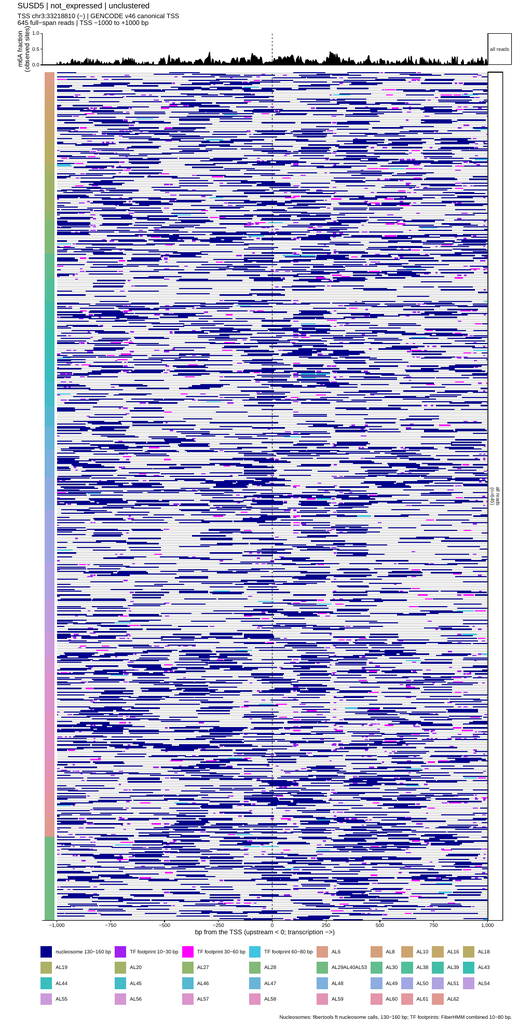

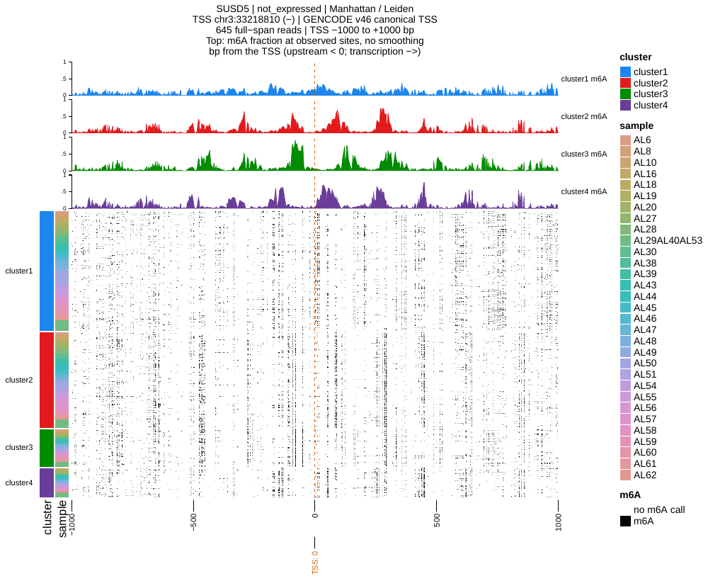

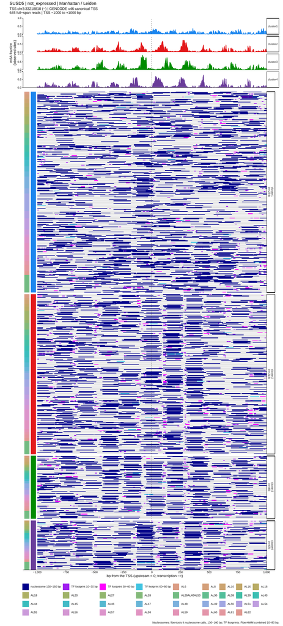

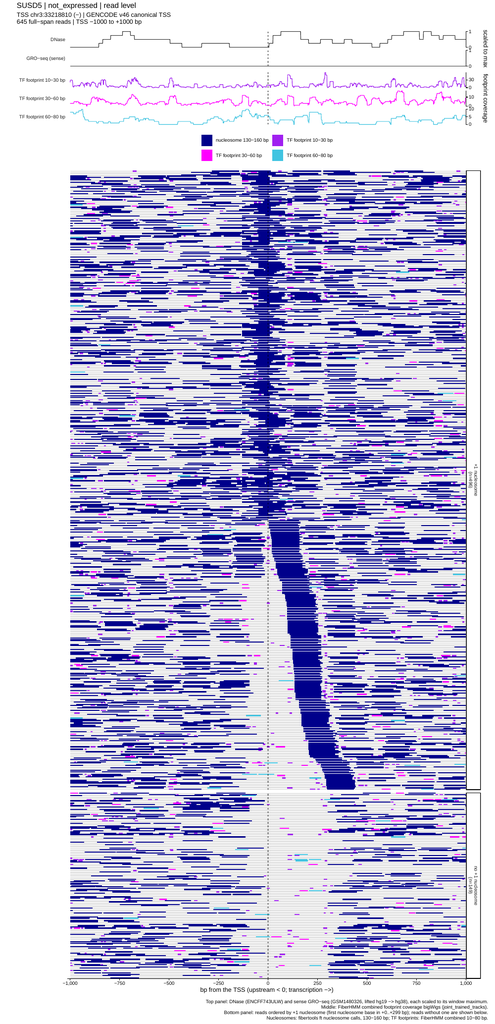